# R Notebook

# Introduction

The impetus for this project came after reading about Bill Connelly’s work on the SP+ rating system for college football(Connelly 2017). SP+ uses five tempo-adjusted team statistics to rank teams both offensively and defensively. The “Five Factors” he uses are efficiency, explosiveness, field position, finishing drives, and turnovers.

The key phrase that sparked my imagination was “Five Factors”. For me, it called back to the book Basketball on Paper by Dean Oliver, wherein Oliver states that there are Four Factors that determine a basketball team’s success (Oliver 2011). Those Four Factors, according to Oliver are field goal shooting, turnovers, rebounding, and free throws.

My thinking was that I could use similar tempo-adjusted basketball statistics and create a model to project team success for basketball teams.

# The Data

College basketball data is widely available on the internet, and the easiest place to gather large amounts of data is basketball-reference.com. All data for this project is courtesy of them.

Data was gathered using the Get Table as CSV function on the basketball-reference website on the pages for school stats in the 2023-24 season summary pages for the men’s and women’s seasons respectively(Sports Reference 2024).

The first thing that we need to do is bring data in that we can work with. The team data and opponent data are in two separate tables, so we need to bind the columns together to make on cohesive data frame, then drop and the duplicate school column. The tables are all in alphabetical order by school name, so we do not need to worry about adding any other sort function. We will also be using a host of different libraries native to R to help with data manipulation, cleaning, visualization, and model building.

Once we have our data combined into one data frame for men’s and one data frame for women’s, we need to apply mutations to get our tempo-adjusted efficiency stats.

A note on the formula used for estimating possessions: different statisticians will use different formulas for estimating possessions. Free throws get difficult because not all trips to the free throw line are take end a possession. Further, not all free throw attempts come from possessions. Different studies have come up with different numbers for how many free throws actually end a possession. There are two shot free throws and there are one-and-ones. Sometimes there is no rebound when the ball gets tipped out of bounds. All this to demonstrate that there is no super clean way to account for free throws.

To that end, I’ve decided to go with the formula that is used by statistician Ken Pomeroy, one of the most widely respected data scientists in the world of college hoops, and using his recommendation of John Hollinger’s free-throw coefficient of 0.44 (Pomeroy 2004).

## Formulas and Explanations for Tempo-Adjusted Statistics

### Possessions

Possessions are an estimation of how many times a team possess the basketball. As discusses above, there are different ways of doing this. The formula we are using is as follows:

$$\text{Possessions} = (\text{FGA} - \text{ORB}) + \text{Turnovers} +
(0.44 \times \text{FTA})$$

### Effective Field Goal % (eFG%)

eFG% is a way to measure a team’s field goal shooting efficiency. It accounts for the fact that a three-point field goal is worth 50% more than a two-point field goal. To demonstrate, a team can score six points by making three two-point field goals, or they can score the same six points by making two three-point field goals. The team that scores by making three-point shots is more efficient.

$$\text{eFG%} = \frac{\text{FGM} + (0.5 \times \text{3PtFGM})}{\text{FGA}}$$

### Turnover Rate (TOV%)

Turnover rate measures the percentage of a team’s possessions that end in a turnover. Using TOV% instead of raw turnover numbers adjusts for pace of play, because a team that plays at a faster pace has more opportunities to turn the ball over.

$$\text{TOV%} = \frac{\text{TOV}}{\text{Poss}}$$

### Rebounding Rate

Rebounding rate measures what percentage of available rebounds a team brought in on either end of the floor. For example, if a team missed 10 shots and they got 2 offensive rebounds, they would have an offensive rebounding rate of 20%. A team’s offensive rebounding rate and their opponent’s defensive rebounding rate will always equal 1.

$$\text{ORB%} = \frac{\text{ORB}}{\text{ORB} + \text{Opponent DRB}}$$

$$\text{DRB%} = \frac{\text{DRB}}{\text{DRB} + \text{Opponent ORB}}$$

### Free Throw Rate (FTRte)

The final tempo-adjusted statistic we’ll be using is free throw rate, not to be confused with free throw percentage. FTRte is a ratio of a teams free throw attempts to their field goal attempts. Free throws are always the most efficient offense, even for teams that are relatively bad shooters from the charity stripe. Some statisticians will use free throw makes divided by field goal attempts, but because we are looking at efficiency numbers and, again, free throws are always efficient, we will use free throw attempts.

$$\text{FTRte} = \frac{\text{FTA}}{\text{FGA}}$$

## Data Preparation

### Assumptions of Normality

The first thing we need to do when making a model is check that all of our data is normally distributed. A basic assumption of nearly all machine learning models is that variables are both independent from each other and normally distributed under a Gaussian Curve (also called a bell curve)(Lehmann 2011). The distributions of our data are shown below, with men’s data shown in blue and women’s data shown in green.

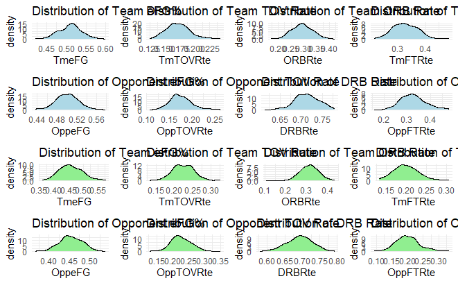

All of the data we have is nearly normally distributed. Some of the statistics have tails to them, but after our scaling, those tails will be taken care of.

### Scaling

Now that we have established that our data are normally distributed, a note on magnitude. All of the data we are using in this model are expressed as percentages. However, what is considered “good” in a particular statistic, may not be considered “good” in another.

To demonstrate, Texas A&M led men’s basketball in offensive rebounding rate at 42.25%. Meanwhile, St. Mary’s led men’s basketball in defensive rebounding rate at 77.93%. Both of these are rebounding statistics and tops in the same division. However, those numbers are nowhere near each other.

Therefore, we need to scale our data. We scale these by finding the mean of each statistic and finding out out how many standard deviations away from the mean each observation is. In statistics, this is also known as finding the Z-Score.

The first ten teams are listed alphabetically below with their scaled data in each category.

Scaled Data for Modeling

| Team | Team eFG% | Team TOV% | ORB% | Team FTRte | Opp. eFG% | Opp. TOV% | DRB% | Opp. FTRte |
| --- | --- | --- | --- | --- | --- | --- | --- | --- |
| Abilene Christian | −1.03 | 0.37 | −0.67 | 1.19 | 0.54 | 1.29 | −0.38 | 1.36 |
| Air Force | 1.07 | 0.89 | −1.37 | −0.69 | 1.84 | 0.37 | −0.99 | 1.21 |
| Akron | 0.45 | −0.13 | 0.32 | −0.23 | −0.60 | −0.18 | 1.21 | −0.80 |
| Alabama | 1.86 | −0.58 | 1.43 | 0.57 | −0.16 | −0.81 | −0.85 | 1.17 |
| Alabama A&M | −1.72 | 2.72 | 0.67 | 3.17 | −0.38 | 0.98 | −1.44 | 2.36 |
| Alabama State | −2.93 | −0.58 | 0.79 | −0.96 | −0.84 | 1.72 | 0.19 | 1.78 |
| Albany (NY) | −0.05 | 0.33 | 0.31 | −0.84 | 0.35 | 0.25 | −0.15 | 1.09 |
| Alcorn State | −0.71 | −0.03 | 1.09 | 1.08 | 2.11 | −0.09 | −0.61 | 0.77 |
| American | 0.69 | −0.03 | −0.23 | −0.97 | 1.54 | −0.13 | 1.23 | −0.50 |
| Appalachian State | 0.65 | −0.95 | 0.35 | −0.33 | −2.69 | −1.27 | 0.43 | −2.11 |

As you can see in the table above, we now have z-scores for all of the statistics we are using and we can move forward with optimizing the weights for each.

## Optimization

I’ve written an objective function that will take different weights as parameters and return the squared errors of the given weights. We’ll start with using Oliver’s weights and we can use the optim() function in R to give us the optimal results.

First, though, we need to split our data into testing data and training data. We’ll be using an 80/20 split.

```
Men's training data sample: 289
Men's test data sample: 73
Women's training data sample 288
Women's test data samle: 72
```

There are two ways that we’ll try to optimize this. The first will be with keeping Oliver’s weights for both the offensive and defensive sides of the ball. The second will be to divide the weights by two. My thinking on this is that there are two halves to all of the statistics that we are looking at - the offensive and defensive sides of the ball.

### Full Weight Results

Here first are the optimization results from using Oliver’s full weights for the men’s data.

```
$par
[1]  0.103323623 -0.001901011  0.010393731  0.035452765 -0.064947905  0.043372778
[7]  0.015801769 -0.049393016

$value
[1] 77.37966

$counts
function gradient
    2981       NA

$convergence
[1] 0

$message
NULL
```

Here now are the optimization results from using Oliver’s full weights on the women’s data.

```
$par
[1]  0.08042503 -0.03380477  0.01840766  0.02992546 -0.07254362  0.07386022  0.06501971
[8] -0.02948148

$value
[1] 74.07852

$counts
function gradient
    2191       NA

$convergence
[1] 0

$message
NULL
```

The coefficients for each statistic are listed in the $par section of the output. In order they represent offensive eFG%, offensive TOV%, ORB%, offensive FTRte, opponent eFG%, opponent TOV%, DRB%, and opponent FTRte.

The $value section of the output gives us our mean square error for each model, and the $counts section tells hows how many iterations it took for the function to converge to a solution.

Finally, the $convergence value of 0 tells us that the optim() function did successfully converge to a solution.

### Half-Weight Results

Now for testing with cutting the weights in half to account for the fact that there is shooting, rebounding, turnover, and free throws on both ends of the floor.

These are the results of the optimization function with the men’s data.

```
$par
[1]  0.103198972 -0.002379747  0.011174447  0.034460830 -0.066014589  0.042081009
[7]  0.014982126 -0.047848824

$value
[1] 77.37927

$counts
function gradient
    1079       NA

$convergence
[1] 0

$message
NULL
```

And here are the results of the optimization function for the women’s data, starting with half of Oliver’s suggested weights as parameters.

```r
half_weight_results_womens<- optim(par = weights_half, fn = womens_obj_fun, control = list(maxit=5000))

print(half_weight_results_womens)
```

```
$par
[1]  0.06082867  0.02612598 -0.01738069  0.02839132 -0.04682894  0.07880166  0.13116099
[8] -0.02424620

$value
[1] 75.37763

$counts
function gradient
    1831       NA

$convergence
[1] 0

$message
NULL
```

# Comparisons

Now that we have a couple of different models to work with, given the coefficients from the optim() function, we can start to look at which is the most accurate.

We’ll do this by creating a new data frame with all of the actual Win/Loss% for each team and the predicted Win/Loss that each model gives us. When we have all of that together we can look at how our residuals are plotted out and it will allow for easy visualization of model performance.

## Residuals

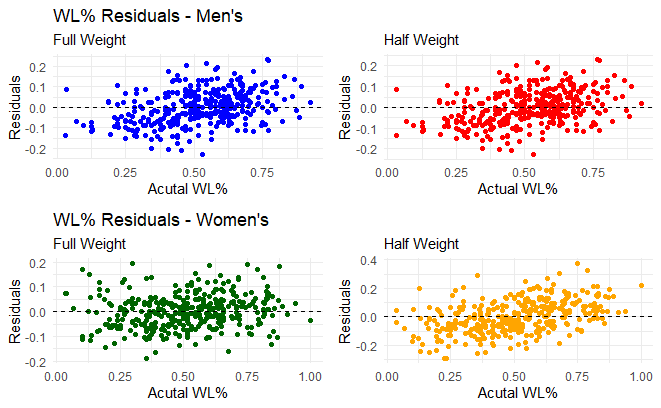

## Actual vs. Predicted

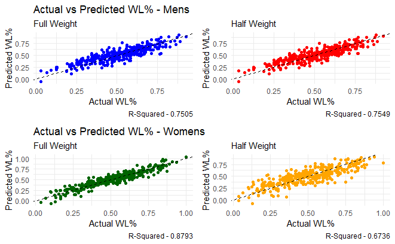

These plots here, along with their captioned R-Squared values, give us a good idea of how accurate each model is. The two men’s models are roughly equally accurate, with both having R-Squared values around 0.75. However, the two women’s models vary drastically, with the model that started with Oliver’s full weights as parameters having an R-Squared value of 0.8793 and the model that started with the half-weights having an R-Squared value of 0.6736. So, of the four that we have, the women’s model is certainly the most accurate.

While that R-Squared value isn’t terrible, I would like to see if we can get a little bit more accurate by developing some alternate models.